# Cause and Effect

Yubo Cao(Netid:yubocao2)

11/1/2019

# PREPARERATION

## Set up libraries and include tests from AMN

## Helper functions for ANM test

```r
test <- function(x, y, reg_model = train_GAMboost, ind_test = indtestHsic, cut_off = 10, verbose = FALSE, detail = FALSE) {
    xToY <- reg_model(x, y)
    yToX <- reg_model(y, x)
    xToYMod <- ind_test(xToY$residuals, x)
    yToXMod <- ind_test(yToX$residuals, y)
    xToY.P <- xToYMod$p.value
    yToX.P <- yToXMod$p.value

    if (xToY.P > 10 * yToX.P) {
        result <- TRUE
    } else if (xToY.P * 10 < yToX.P) {
        result <- FALSE
    } else {
        result <- NA
    }

    if (verbose) {
        message("P value for forward is ", xToY.P, ", P value for backword is ", yToX.P, " result is ", ifelse(is.na(result), "Inconclusive", result))
    }

    ans <- c(result, xToY.P, yToX.P)
    if (detail) {
        ans <- c(result, xToY.P, as.vector(xToY$model$coeff), yToX.P, as.vector(yToX$model$coeff))
    }

    ans
}

shift <- function(x, col_names, lags = 1) {
    name <- "y"
    x[, name] <- NA
    x[1 : (nrow(x) - lags), name] <- x[(lags + 1) : nrow(x), col_names]
    x = x[1 : (nrow(x) - lags), ]
}

file_test <- function(file, col_names, reg_model = train_GAMboost, ind_test = indtestHsic, cut_off = 10, lags = 1, collection = 1 : 12, verbose = FALSE, detail = FALSE) {
    data <- read.csv(file, skip = 11, stringsAsFactors = FALSE)
    data[data == " M"] <- NA
    data$x <- as.numeric(data[, col_names])
    data <- data[, c("Date", "x")]
    data <- na.omit(shift(data, "x", lags))

    collection_result <- matrix(0, length(collection), ifelse(detail, 7, 3))
    for (i in collection) {
        curr <- data[month(data$Date) %in% i, ]
        result <- test(curr$x, curr$y, reg_model = reg_model, verbose = verbose, detail = detail)
        collection_result[i, ] = c(ifelse(is.na(result[1]), -1, as.numeric(result)[1]), result[2: length(result)])
    }

    return(list(collection_result, data))
}

var_test_oneway <- function(data, x = "x", y = "y", quane = seq(0, 1, 0.1)) {
    result <- rep(0, length(quan - 1))
    q <- quantile(data[, x], probs = quan)
    for (i in 1 : (length(result) - 1)) {
        result[i] = var(data[data[, x] >= q[i] & data[, x] < q[i + 1], y], na.rm = TRUE)
    }

    result
}

var_test <- function(data, x = "x", y = "y", quantile = seq(0, 1, 0.1), threshold = 2) {
    xToY <- var(var_test_oneway(data, x, y), na.rm = TRUE)
    yToX <- var(var_test_oneway(data, y, x), na.rm = TRUE)

    if (xToY > threshold * yToX) {
        return("X~Y")
    } else if (yToX > threshold * xToY) {
        return("Y~X")
    } else {
        return("Inconclusive")
    }
}
```

# PROCESSING

## 100 Places weather datasets

```r
result_coef <- data.frame(FileName = character(),
                          TestParameter = character(),
                          TestLag = integer(),
                          RegressionModel = character(),
                          Collection = factor(),
                          ForwardPValue = double(),
                          ForwardIntersection = double(),
                          ForwardBeta = double(),
                          BackwardPValue = double(),
                          BackwardIntersection = double(),
                          BackwardBeta = double(),
                          Std = double(),
                          Result = factor())

count <- 0
for (file in files) {
    message("Start ", count, " testing file: ", file)
    count <- count + 1
    f_result <- file_test(file = file,
                          col_names = "Max.Temperature",
                          reg_model = train_linear,
                          lags = 1,
                          detail = TRUE)

    data <- f_result[[2]]
    f_result <- f_result[[1]]

    for (r in (1 : nrow(f_result))) {
        curr_result <- factor("TRUE")
        if (f_result[r, 1] == 0 ) {
            curr_result <- factor("FALSE")
        } else if (f_result[r, 1] == -1 ) {
            curr_result <- factor("Inconclusive")
        }

        curr_month <- data[month(data$Date) %in% r, ]
        curr_month$day <- day(curr_month$Date)
        curr_std <- (curr_month %>% group_by(day) %>% summarise(sd = sd(x)) %>% summarise(mean = mean(sd)))$mean

        curr <- list(FileName = file,
                     TestParameter = "Max.Temperature",
                     TestLag = 1,
                     RegressionModel = "train_liear",
                     Collection = r,
                     ForwardPValue = f_result[r, 2],
                     ForwardIntersection = f_result[r, 3],
                     ForwardBeta = f_result[r, 4],
                     BackwardPValue = f_result[r, 5],
                     BackwardIntersection = f_result[r, 6],
                     BackwardBeta = f_result[r, 7],
                     Std = curr_std,
                     Result = curr_result)

        result_coef <- rbind(result_coef, curr, stringsAsFactors = FALSE)
    }
}

write.csv(result_coef, "../AllLinear.csv", row.names = FALSE)
```

## Additional data sets: 42, 43, 44 in pairs

```r
f42 <- read.delim("../pair0042.txt", header = FALSE, stringsAsFactors = FALSE)
f43 <- read.delim("../pair0043.txt", header = FALSE, sep = "", stringsAsFactors = FALSE)
f44 <- read.delim("../pair0044.txt", header = FALSE, sep = "", stringsAsFactors = FALSE)

f42_result <- test(f42$V1, f42$V2, reg_model = train_linear, detail = TRUE)
f43_result <- test(f43$V1, f43$V2, reg_model = train_linear, detail = TRUE)
f44_result <- test(f44$V1, f44$V2, reg_model = train_linear, detail = TRUE)
```

# ANALYSIS

We first look at the accuracy of the tests in 100 places datasets.

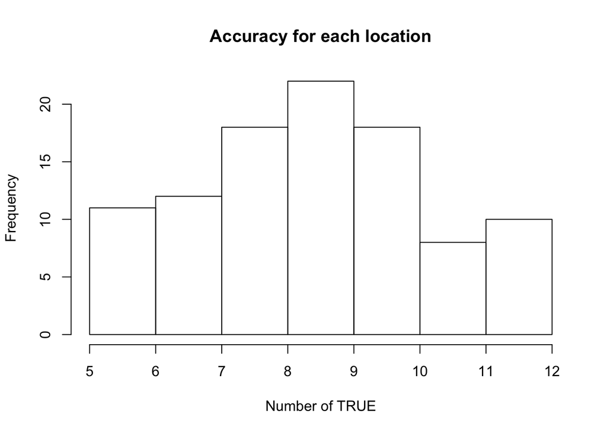

```r
result_coef <- read.csv("../AllLinear.csv", stringsAsFactors = FALSE)
xx <- result_coef

accu <- xx %>% group_by(FileName) %>% filter(Result == "TRUE") %>% count() %>% arrange(desc(n)) %>% ungroup %>% as.data.frame()

hist(accu$n, xlab = "Number of TRUE", main = "Accuracy for each location")
```

```r
message("Overall accuracy is ", sum(xx$Result == "TRUE") / nrow(xx))
```

```
## Overall accuracy is 0.731666666666667
```

The overall accuracy is very good.

Let’s take a look at which month has the best performance.

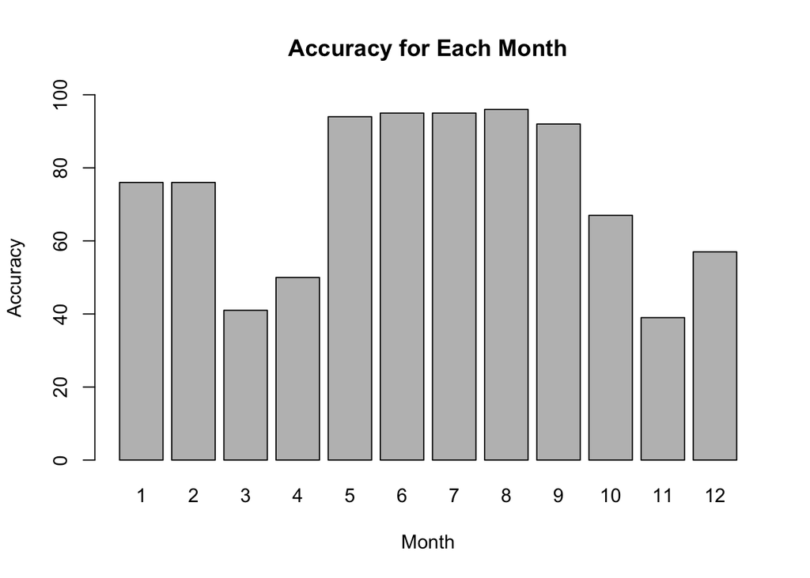

```r
accu <- xx %>% group_by(Collection) %>% filter(Result == "TRUE") %>% count() %>%  ungroup %>% as.data.frame()

month_accu <- accu$n
names(month_accu) <- accu$Collection
barplot(month_accu, xlab = "Month", ylab = "Accuracy", main = "Accuracy for Each Month", ylim = c(0, 100))
```

We notice that the accuracy is best in summer, then winter, then other seasons.

We check the stability of the test.

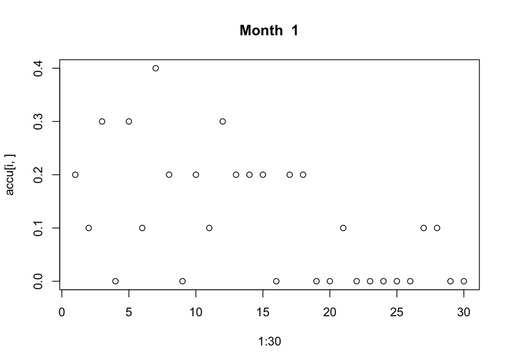

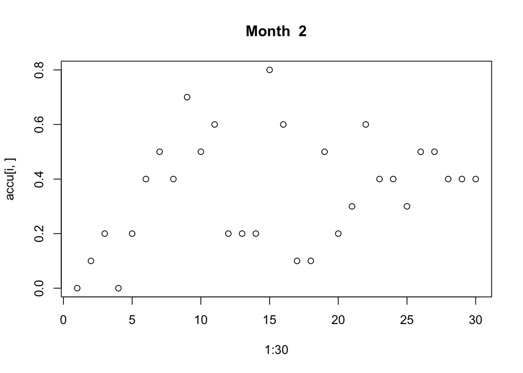

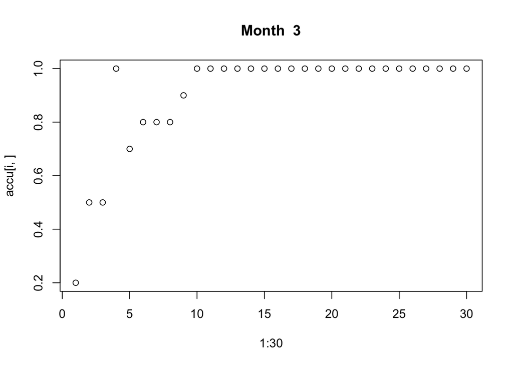

```r
file = "AR_NEWPORT.csv"
data <- read.csv(file, skip = 11, stringsAsFactors = FALSE)
data[data == " M"] <- NA
data$x <- as.numeric(data[, "Max.Temperature"])
data <- data[, c("Date", "x")]
data_All <- na.omit(shift(data, "x", 1))

accu <- matrix(rep(0, 30 * 3), nrow = 3)
for (i in seq(100, 3000, 100)) {

  for (r in 1:3) {
    total <- 0
    data <- data_All[month(data_All$Date) %in% r, ]
    for (j in 1:10) {
      xx <- data[sample(1 : nrow(data), i), ]
      yy <- test(as.numeric(xx$x), as.numeric(xx$y), reg_model = train_linear, detail = TRUE)

      curr_result <- factor("X->Y")
      if (is.na(yy[1])) {
          curr_result <- factor("Inconclusive")
      } else if (yy[1] == 0) {
          curr_result <- factor("Y->X")
      }

      if (curr_result == "X->Y") {
        total <- total + 1
      }
    }

    accu[r, i / 100] = total / 10.0
  }

}

for (i in 1 : 3) {
  plot(1:30, accu[i, ], main = paste("Month ", i))
}
```

```r
xx <- result_coef
a <- xx %>% group_by(Collection) %>% summarize_at(vars(c(starts_with("Forward"), starts_with("Backward"), "Std")),list(mean = mean, sd = sd)) %>% as.data.frame()

plot(x = 1 : 12, type = "n")
for (i in 1 : 14) {
  points(a[, i + 1], col = rainbow(14)[i], type = "l")
  message("The correlation between Accuracy and ", colnames(a)[i + 1], " is ", cor(month_accu, a[, i + 1]))
}
```

```
## The correlation between Accuracy and ForwardPValue_mean is 0.436527703362221
```

```
## The correlation between Accuracy and ForwardIntersection_mean is 0.680632917621214
```

```
## The correlation between Accuracy and ForwardBeta_mean is -0.762240276386162
```

```
## The correlation between Accuracy and BackwardPValue_mean is -0.0615083212880744
```

```
## The correlation between Accuracy and BackwardIntersection_mean is 0.674187381638183
```

```
## The correlation between Accuracy and BackwardBeta_mean is -0.746721004578061
```

```
## The correlation between Accuracy and Std_mean is -0.700368952299064
```

```
## The correlation between Accuracy and ForwardPValue_sd is 0.446787500847445
```

```
## The correlation between Accuracy and ForwardIntersection_sd is -0.272075093975711
```

```
## The correlation between Accuracy and ForwardBeta_sd is 0.417043652492806
```

```
## The correlation between Accuracy and BackwardPValue_sd is -0.0471512045299874
```

```
## The correlation between Accuracy and BackwardIntersection_sd is -0.202418434211187
```

```
## The correlation between Accuracy and BackwardBeta_sd is 0.405518855842696
```

```
## The correlation between Accuracy and Std_sd is -0.587528849033615
```

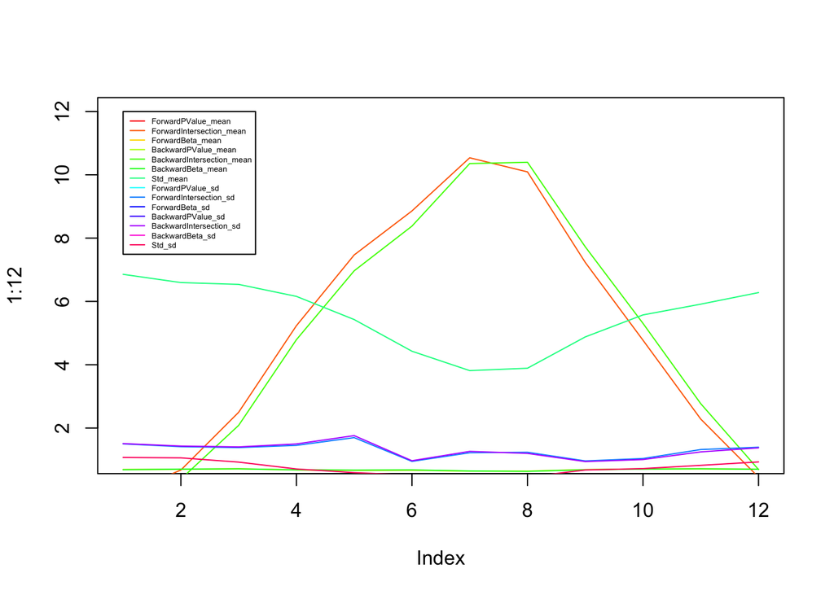

```r
legend(x = 1, y = 12, legend = colnames(a)[-1], col = rainbow(14), lty = 1, cex = 0.4)
```

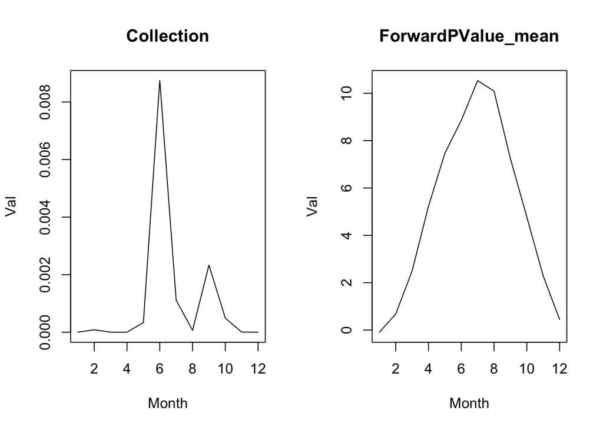

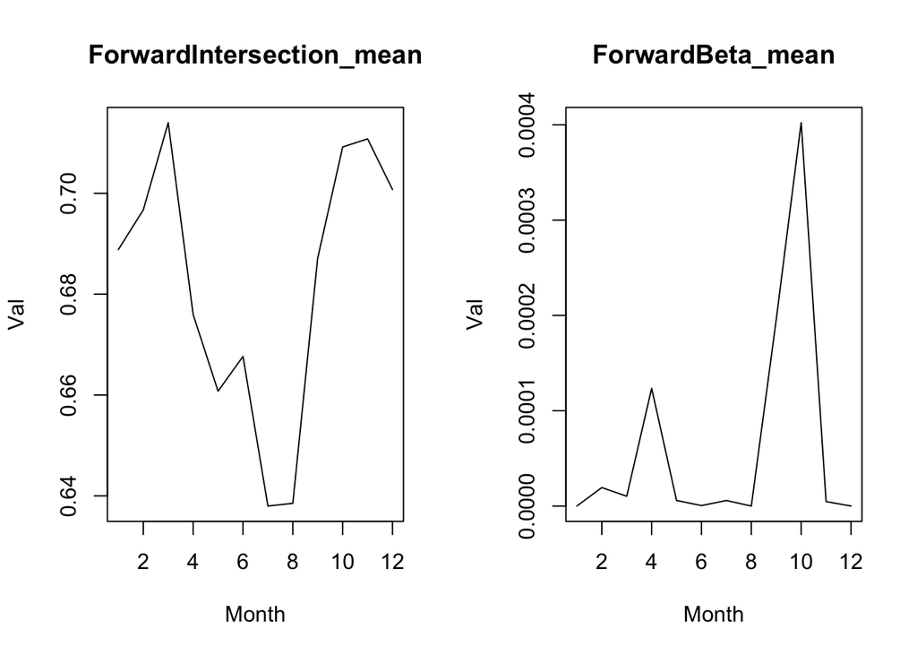

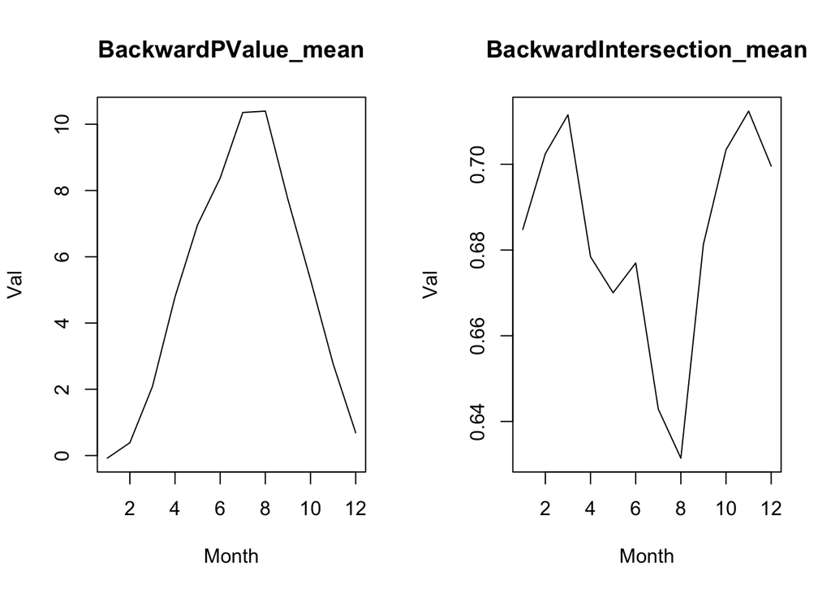

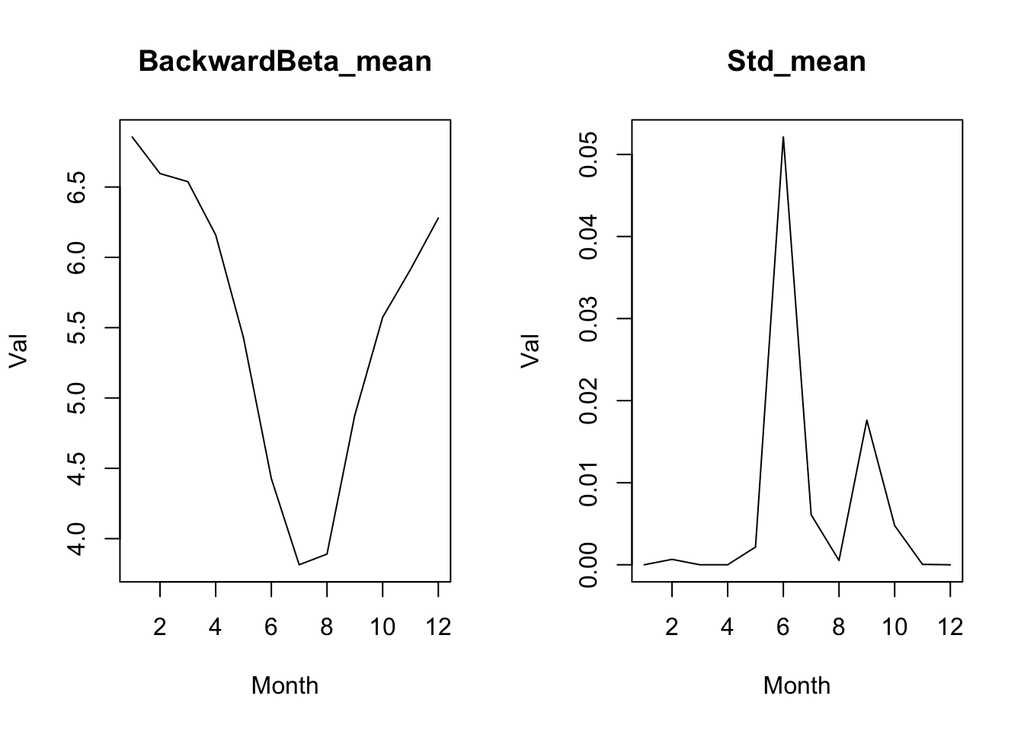

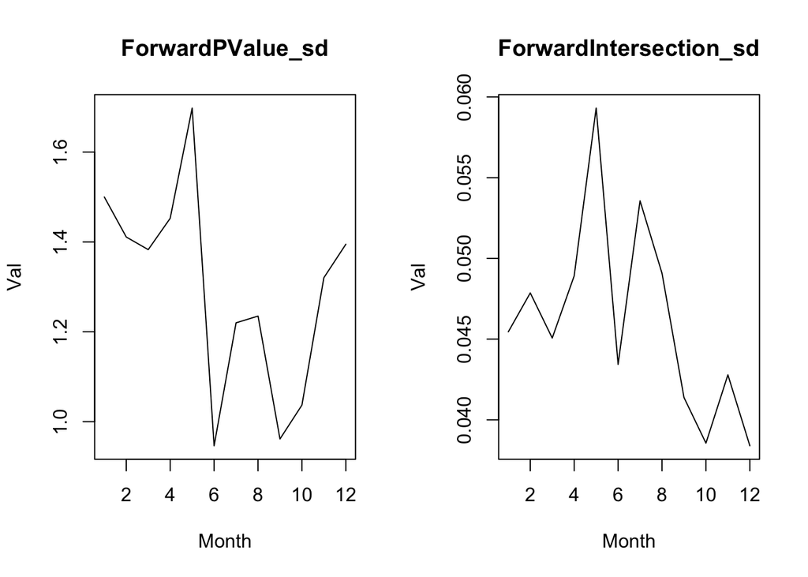

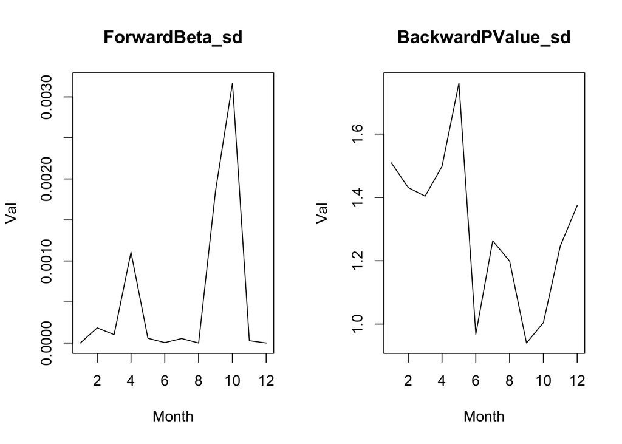

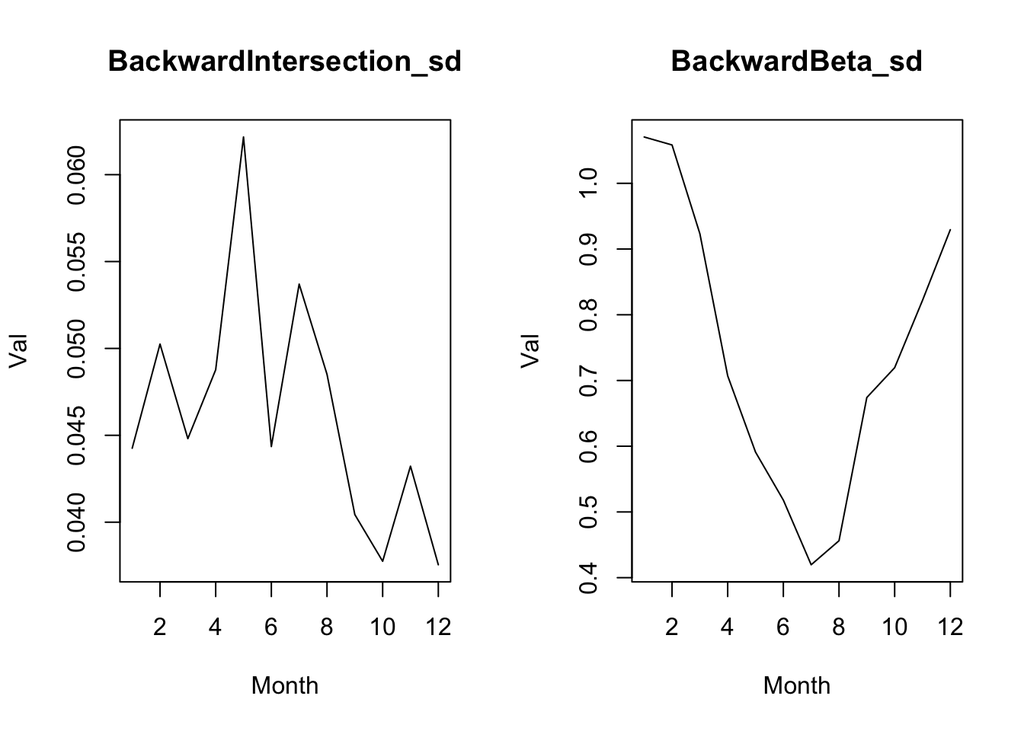

```r
par(mfrow = c(1, 2))
for (i in 1 : 14) {

  plot(a[, i + 1], type = "l", pch = i, main = colnames(a)[i], xlab = "Month", ylab = "Val")
}
```

```r
par(mfrow = c(1, 1))
```

A regression test on ForwardBeta

```r
set.seed(541)
whole <- result_coef[, c("FileName", "Collection", "ForwardBeta", "ForwardIntersection", "Std", "Result")]
whole[whole$Result == "Inconclusive" | whole$Result == "FALSE", "Result"] = 0
whole[whole$Result == "TRUE", "Result"] = 1
whole[, "Result"] <- as.numeric(whole[, "Result"])

all_train_ind <- sample(1200, 800)
all_train <- whole[all_train_ind, ]
all_test <- whole[-all_train_ind, ]

accuracy <- rep(0, 10)
model <- list()
for (i in 1 : 10) {
    train_ind <- sample(800, 600)
    train_partial <- all_train[train_ind, ]
    test_partial <- all_train[-train_ind, ]
    m <- glm(Result ~ ForwardBeta + Std + ForwardIntersection, data = train_partial)
    p <- predict(m, test_partial, type = "response")
    r <- ifelse(p > 0.5, 1, 0)
    accuracy[i] <- sum(r == test_partial$Result) / 200.0
    model[[i]] <- m
}

model <- model[[which.max(accuracy)]]
p <- predict(model, all_test, type = "response")
r <- ifelse(p > 0.5, 1, 0)
all_accu <- sum(r == all_test$Result) / 400.0

message("The accuracy is ", all_accu)
```

```
## The accuracy is 0.7
```

Now select one file that performs well to do a stable test

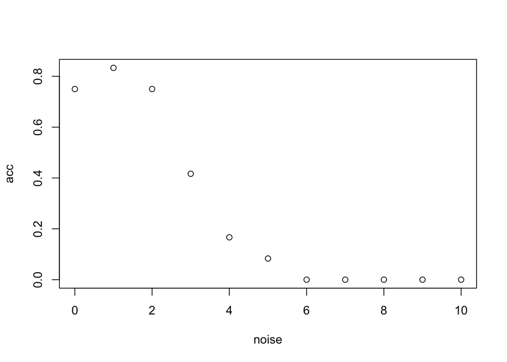

```r
good <- result_coef %>% filter(Result == "TRUE") %>% group_by(FileName) %>% count() %>% arrange(n) %>% filter(n >= 9)
good_files <- good$FileName

file <- good_files[5]
data <- read.csv(file, skip = 11, stringsAsFactors = FALSE)
data[data == " M"] <- NA
data$x <- as.numeric(data[, "Max.Temperature"])
data <- data[, c("Date", "x")]
data <- na.omit(shift(data, "x", 1))

mult <- 1
noise <- seq(0, 10, 1)
temp <- data
acc <- rep(0, length(noise))
curr_noise_x <- rnorm(nrow(data))
curr_noise_y <- rnorm(nrow(data))
for (i in 1 : length(noise)) {
    temp$x <- data$x * mult + curr_noise_x * noise[i]
    temp$y <- data$y * mult + curr_noise_y * noise[i]
    partial <- 0
    for (r in 1 : 12) {
        curr <- temp[month(temp$Date) %in% r, ]
        curr_r <- test(curr$x, curr$y, train_linear)[1]
        if (!is.na(curr_r) & curr_r == 1) {
            partial <- partial + 1
        }
    }

    acc[i] <- partial / 12.0
}

plot(noise, acc)
```

Notice that here the sd of the difference of the consecutive days is 4.326203. Notice that when noise is larger or equal to 8, approximately two sigma, the outputs are all NAs given zero accuracy.

# The Cause and Effect pairs

```r
pairs <- list.files("../pairs")
pairs <- grep("pair\\d{4}.txt", pairs, value = TRUE)
pair_coef <- data.frame(FileName = character(),
                        ForwardPValue = double(),
                        ForwardIntersection = double(),
                        ForwardBeta = double(),
                        BackwardPValue = double(),
                        BackwardIntersection = double(),
                        BackwardBeta = double(),
                        Result = factor())

for (pair in pairs) {
  xx <- read.delim(paste("../pairs/", pair, sep = ""), header = F, sep = "", stringsAsFactors = F)
  if (ncol(xx) != 2 || (length(unique(xx$V2)) == 2 && all(sort(unique(xx$V2)) == c(0, 1)))) {
    next
  }

  message("Pair Name: ", pair, " number of cols ", ncol(xx))

  yy <- test(as.numeric(xx$V1), as.numeric(xx$V2), reg_model = train_linear, detail = TRUE)

  curr_result <- factor("X->Y")
  if (is.na(yy[1])) {
      curr_result <- factor("Inconclusive")
  } else if (yy[1] == 0) {
      curr_result <- factor("Y->X")
  }

  curr <- list(FileName = pair,
               ForwardPValue = yy[2],
               ForwardIntersection = yy[3],
               ForwardBeta = yy[4],
               BackwardPValue = yy[5],
               BackwardIntersection = yy[6],
               BackwardBeta = yy[7],
               Result = curr_result)
  pair_coef <- rbind(pair_coef, curr, stringsAsFactors = FALSE)
}

write.csv(pair_coef, "../Allpair.csv", row.names = FALSE)
```

Let’s get a closer look at pair43, we take samples of them and do tests to check if that helps.

```r
pair <- "pair0043.txt"
pair_43 <- read.delim(paste("../pairs/", pair, sep = ""), header = F, sep = "", stringsAsFactors = F)

total <- 0

for (i in 1 : 10) {
  xx <- pair_43[sample(1 : (nrow(pair_43)), 1000), ]
  yy <- test(as.numeric(xx$V1), as.numeric(xx$V2), detail = F)
  curr_result <- factor("X->Y")
  if (is.na(yy[1])) {
      curr_result <- factor("Inconclusive")
  } else if (yy[1] == 0) {
      curr_result <- factor("Y->X")
  }

  message("The result is ", curr_result)
}
```

```
## The result is X->Y
## The result is X->Y
## The result is X->Y
## The result is X->Y
```

```
## The result is Y->X
```

```
## The result is X->Y
## The result is X->Y
## The result is X->Y
## The result is X->Y
## The result is X->Y
```

```r
message("The whole accuracy is ", (total / 10.0))
```

```
## The whole accuracy is 0
```